# Fire Risk - Exploratory Analysis

### Load Data

Download fire incident data from 2003 onwards from the below url and load the data

https://data.sfgov.org/Public-Safety/Fire-Incidents/wr8u-xric

### Data cleanup

- There are duplicate rows for a lot of incidents. They have been consolidated
- Incidents have been consoldated into types based on National Fire Incident Reporting System (NFIR) definitions

### Some insights

#### 1. Exploring types of incidents

- Majority of the incidents are false alarms, followed by
- Rescue, EMS and other service calls and then
- Fires

A recent report shows that SF Fire Dept is spending $100,000 a day on overtime.

http://www.nbcbayarea.com/news/local/San-Francisco-Fire-Shells-Out-100000-a-Day-on-Overtime-Amid-Staffing-Shortage-387047391.html

The false alarms seem to add a lot to the workload. It would be interesting to see what kind of educational and other initiatives the city undertakes to reduce the number of false alarms.

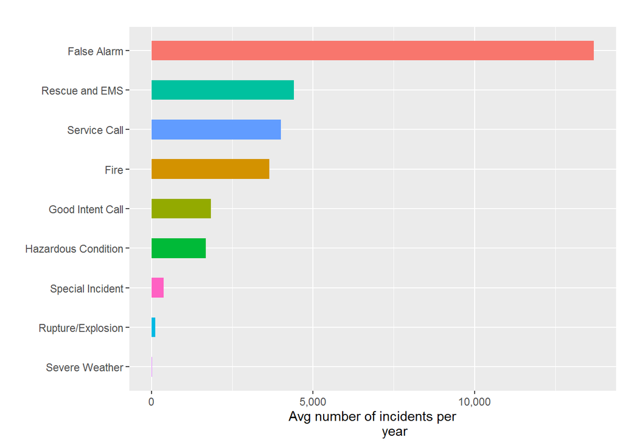

#### 2. Trend of all fire incidents by year

- Number of fire incidents have been steady over the last decade with a dip in 2014

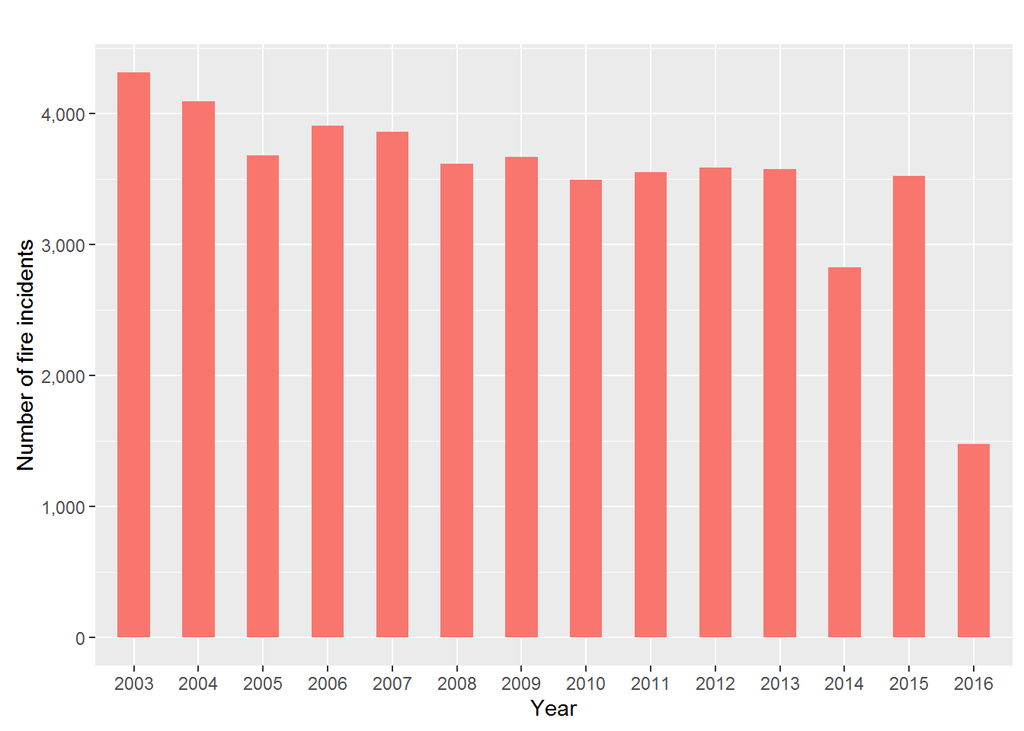

#### 3. Trend of fire incidents by month

- There is a spike in average number of incidents in Jan
- The distribution for the rest of the year seems to be fairly even

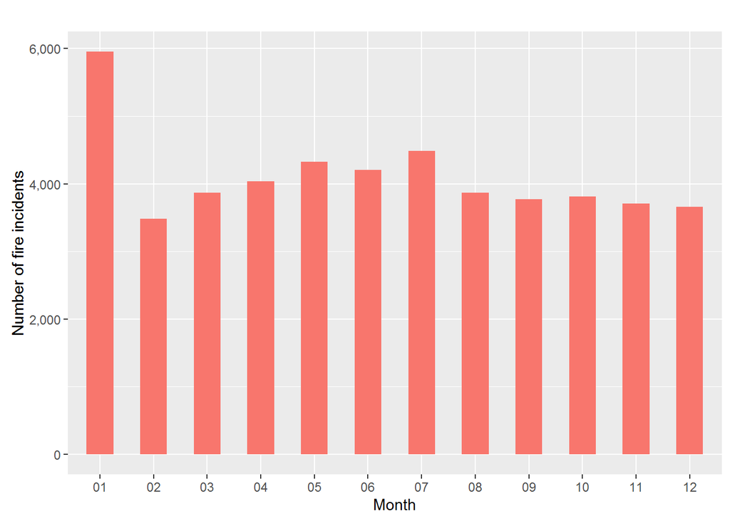

#### 4. Fire incidents by neighborhood

- Mission and Tenderloin have the most number of fires per year

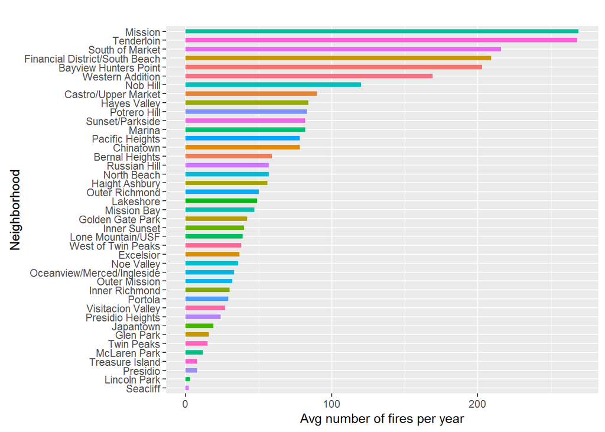

#### 5. Trend of fire incidents by top neighborhoods

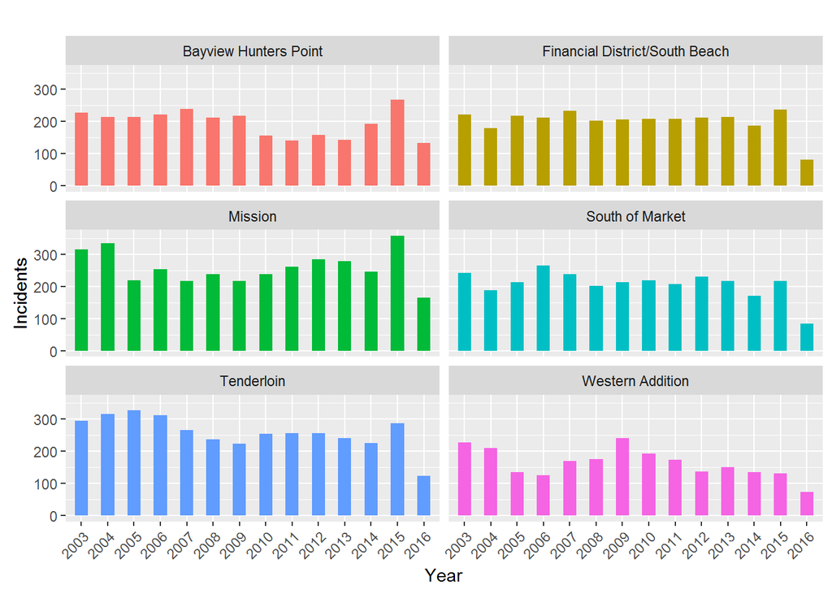

#### 6. Fire incident rate in 2015 - Mission & Tenderloin

- Fire incident rate per population of 1,000 (based on 2010 population data)

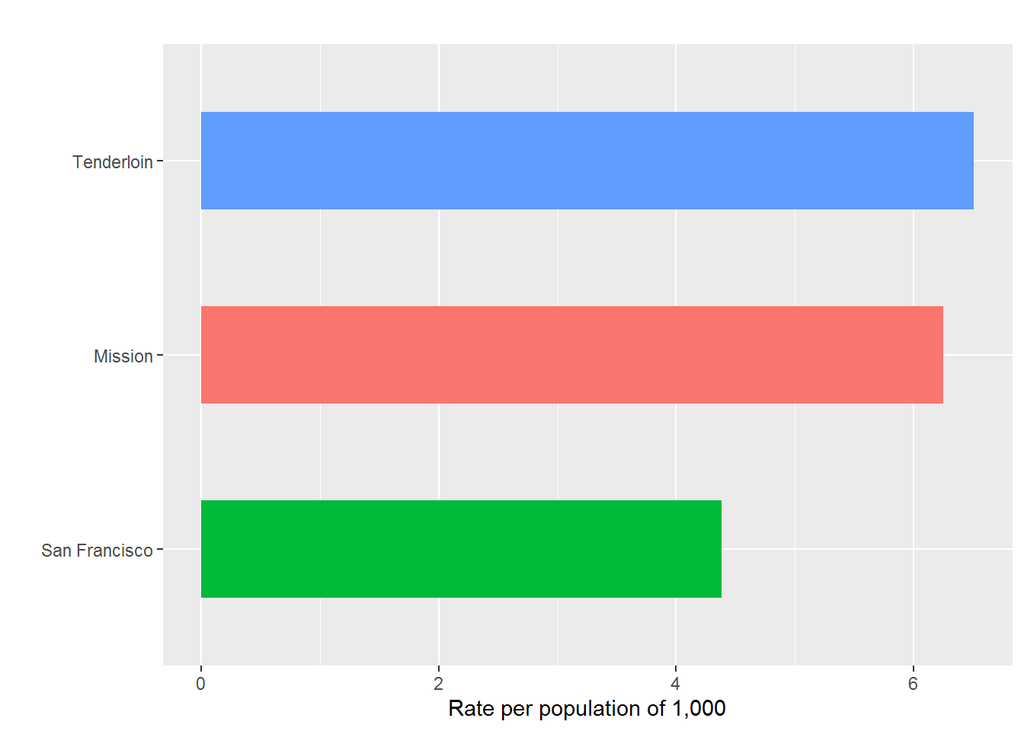